# VR Expriment #1 Report

Songyi Zheng

4/3/2022

# Data

The dataset “VR_Data.csv” which be used in this project was contructed by myself though doing the VR-based education expriment.

## Read and inspect data

```r
# read the file in
data <- read_csv("data/VR_Data.csv")

# inspect the data
glimpse(data)
```

```
## Rows: 4
## Columns: 11
## $ Name          <chr> "Jiahui Wang", "Linpeng Sun", "Qiuchen Zhang", "Runnan …
## $ Gender        <chr> "female", "male", "female", "male"
## $ Age_Group     <chr> "master", "master", "PhD", "undergraduate"
## $ Exp_ID        <dbl> 1, 1, 1, 1
## $ Exp_Group     <chr> "VR", "Text", "VR", "VR"
## $ Edu_Content   <chr> "Valley of the Temples", "Valley of the Temples", "Vall…
## $ Exam_Accuracy <dbl> 0.8, 0.6, 1.0, 0.8
## $ VR_Exp        <chr> "no", "no", "no", "yes"
## $ Dizziness     <chr> "yes", "no", "yes", "no"
## $ Headache      <chr> "no", "no", "no", "no"
## $ Nausea        <chr> "no", "no", "yes", "no"
```

# Research Question #1

> Are there any significant differences in effectiveness in the application of VR-based educational tools between students of different age groups?

```r
# Get VR expriment group data
vr_data <- data %>%
  filter(Exp_Group == "VR")

# Get text expriment group data
text_data <- data %>%
  filter(Exp_Group == "Text")
```

## Linear Regression Model

Let’s run a simple linear regression, so we can determine whether age groups are different in terms of the exam accuracy they are given.

```r
# create the linear regression model
model_vr_data <- lm(Exam_Accuracy ~ Age_Group,
                    data = vr_data)

# print the result
summary(model_vr_data)
```

```
##
## Call:
## lm(formula = Exam_Accuracy ~ Age_Group, data = vr_data)
##
## Residuals:
## ALL 3 residuals are 0: no residual degrees of freedom!
##
## Coefficients:
##                          Estimate Std. Error t value Pr(>|t|)
## (Intercept)             8.000e-01         NA      NA       NA
## Age_GroupPhD            2.000e-01         NA      NA       NA
## Age_Groupundergraduate -1.178e-16         NA      NA       NA
##
## Residual standard error: NaN on 0 degrees of freedom
## Multiple R-squared:      1,  Adjusted R-squared:    NaN
## F-statistic:   NaN on 2 and 0 DF,  p-value: NA
```

We will use the `effects` library to look at these means and confidence intervals based on our linear regression model.

```r
library(effects)

effect("Age_Group", model_vr_data) %>%
  data.frame()
```

```
##       Age_Group fit  se lower upper
## 1        master 0.8 NaN   NaN   NaN
## 2           PhD 1.0 NaN   NaN   NaN
## 3 undergraduate 0.8 NaN   NaN   NaN
```

Let’s plot these numbers so we can compare groups more easily.

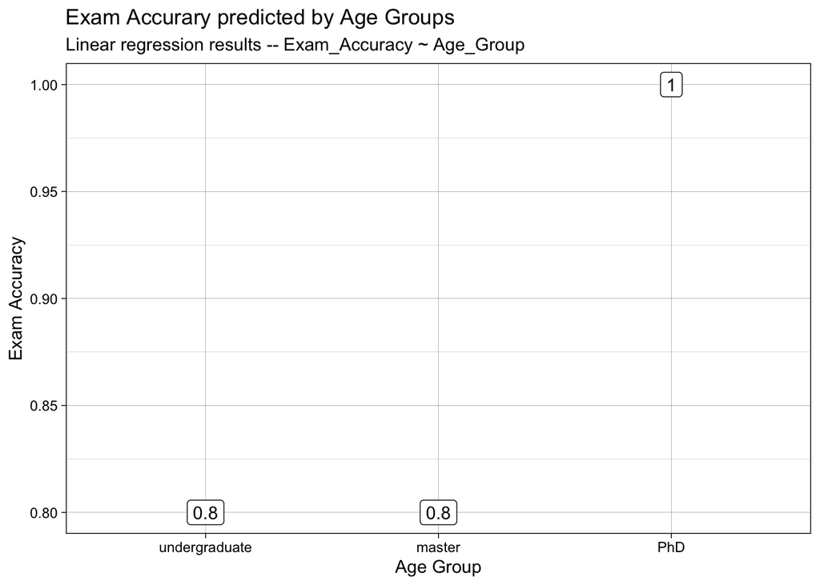

```r
effect("Age_Group", model_vr_data) %>%
  data.frame() %>%
  ggplot(aes(x = reorder(Age_Group, fit),
             y = fit,
             ymin = lower,
             ymax = upper,
             label = round(fit, digits = 2))) +
  geom_errorbar(width = .5) +
  geom_label() +
  theme_linedraw() +
  labs(title = "Exam Accurary predicted by Age Groups",
       subtitle = "Linear regression results -- Exam_Accuracy ~ Age_Group",
       x = "Age Group",
       y = "Exam Accuracy")
```

## Data Visualization - Bar Plot

> What is the distribution of exam accuracy across the different age groups?

```r
# create a new data frame named "vr_score_data" with the summarization
# of the data
vr_score_data <- vr_data %>%
  group_by(Age_Group) %>%
  summarize(mean_accuracy = mean(`Exam_Accuracy`, na.rm = TRUE))
vr_score_data$Exp_Group = "VR"

# create a new data frame named "text_score_data" with the summarization
# of the data
text_score_data <- text_data %>%
  group_by(Age_Group) %>%
  summarize(mean_accuracy = mean(`Exam_Accuracy`, na.rm = TRUE))
text_score_data$Exp_Group = "Text"

# combine dataframe "vr_score_data" and "text_score_data"
score_data = rbind(vr_score_data, text_score_data)
```

Now, create a bar plot mapping the Age Group to x and the mean of accuracy to y.

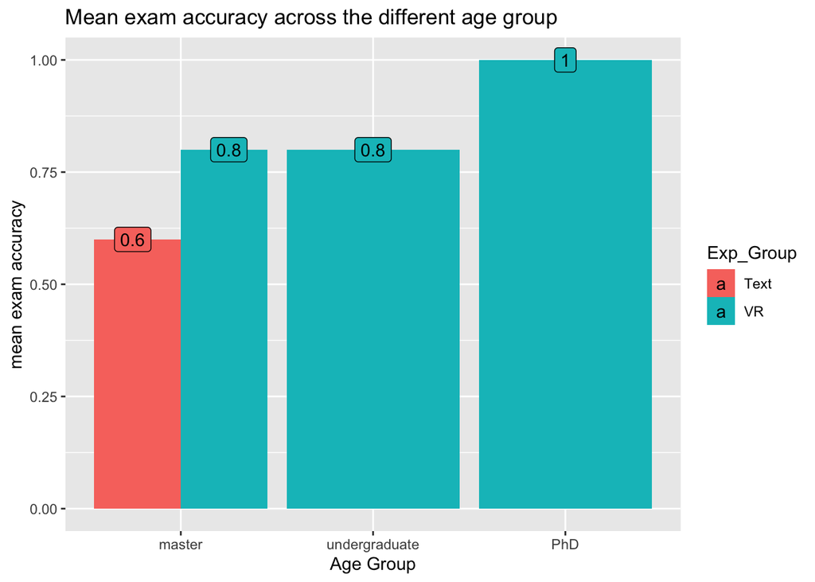

```r
score_data %>%
  ggplot(aes(x = reorder(Age_Group, mean_accuracy),
             y = mean_accuracy,
             fill = Exp_Group)) +
  geom_bar(stat = "identity",
           position = "dodge") +
  geom_label(aes(label = round(mean_accuracy, digits = 2)),
             position = position_dodge(width = 1)) +
  #theme_linedraw() +
  #scale_fill_colorblind() +
  labs(y = "mean exam accuracy",
       x = "Age Group") +
  labs(title = "Mean exam accuracy across the different age group")
```

# Research Question #2

> Will prolonged use of VR apps during education have an impact on students’ health?

## line plot

First, create a new data frame “dizz_data” contains the expriment ID and number of student feel dizziness in VR expriment group

```r
# create a new data frame named "dizz_data" with the summarization
# of the data
dizz_data <- vr_data %>%
  group_by(Exp_ID) %>%
  summarize(num_dizz = sum(`Dizziness`== "yes", na.rm = TRUE))
```

Now,let’s draw a line graph of how students experience dizziness using the VR device as the experiment progresses

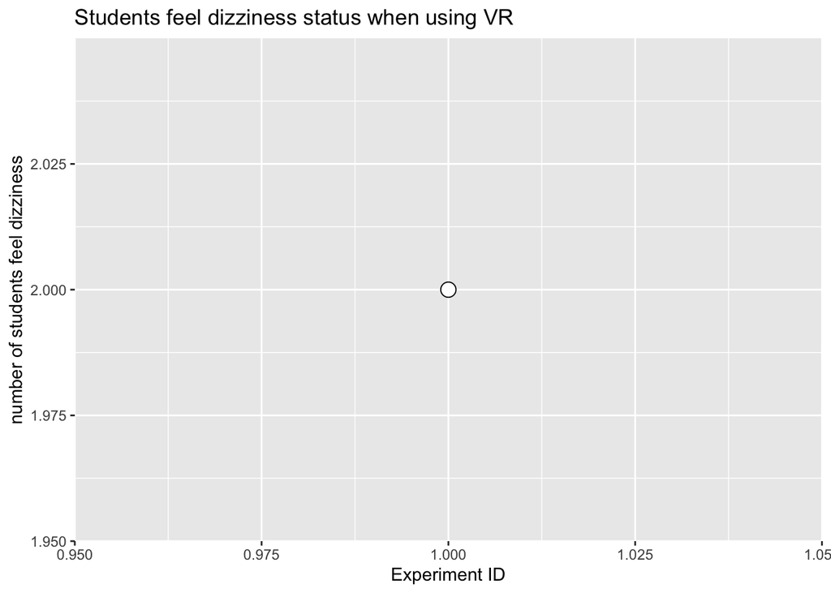

```r
ggplot(dizz_data, aes(x = Exp_ID,
                      y = num_dizz)) +
  geom_line() +
  geom_point(size = 4, shape = 21, fill = "white") +
  labs(x = "Experiment ID",
       y = "number of students feel dizziness") +
  labs(title = "Students feel dizziness status when using VR")
```

Secondly, create a new data frame “headache_data” contains the expriment ID and number of student feel headache in VR expriment group

```r
# create a new data frame named "headache_data" with the summarization
# of the data
headache_data <- vr_data %>%
  group_by(Exp_ID) %>%
  summarize(num_headache = sum(`Headache`== "yes", na.rm = TRUE))
```

Now,let’s draw a line graph of how students experience headache using the VR device as the experiment progresses

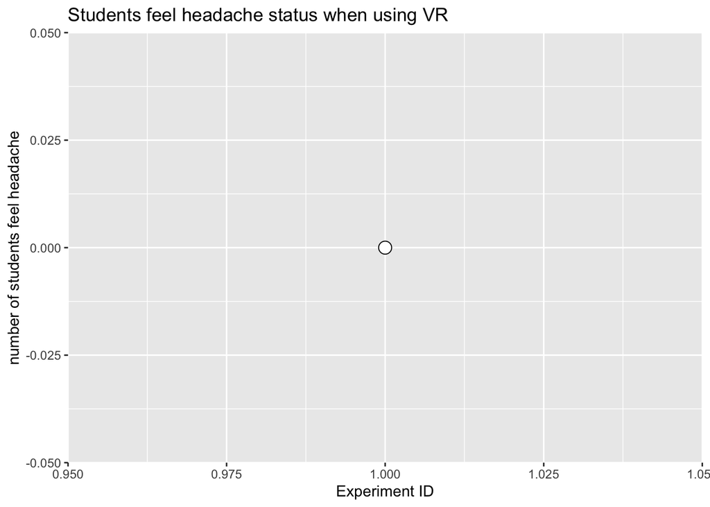

```r
ggplot(headache_data, aes(x = Exp_ID,
                          y = num_headache)) +
  geom_line() +
  geom_point(size = 4, shape = 21, fill = "white") +
  labs(x = "Experiment ID",
       y = "number of students feel headache") +
  labs(title = "Students feel headache status when using VR")
```

Then, create a new data frame “nausea_data” contains the expriment ID and number of student feel nausea in VR expriment group

```r
nausea_data <- vr_data %>%
  group_by(Exp_ID) %>%
  summarize(num_nausea = sum(`Nausea`== "yes", na.rm = TRUE))
```

Now,let’s draw a line graph of how students experience nausea using the VR device as the experiment progresses

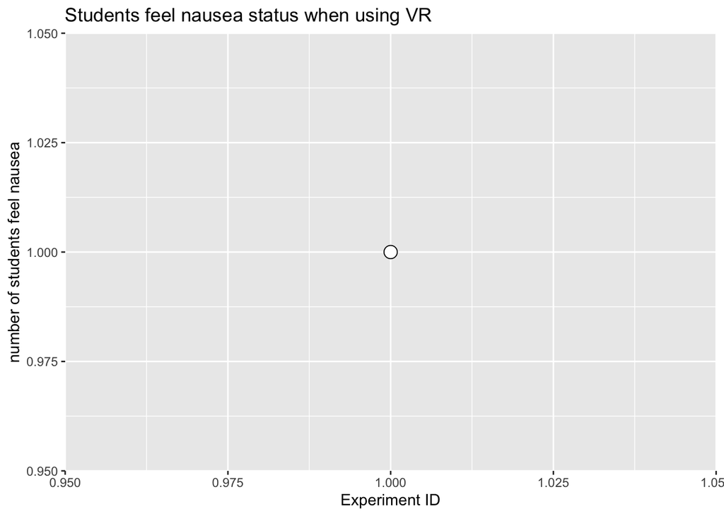

```r
ggplot(nausea_data, aes(x = Exp_ID,
                        y = num_nausea)) +
  geom_line() +
  geom_point(size = 4, shape = 21, fill = "white") +
  labs(x = "Experiment ID",
       y = "number of students feel nausea") +
  labs(title = "Students feel nausea status when using VR")
```

Finally, we use a line plot to show the summarize status

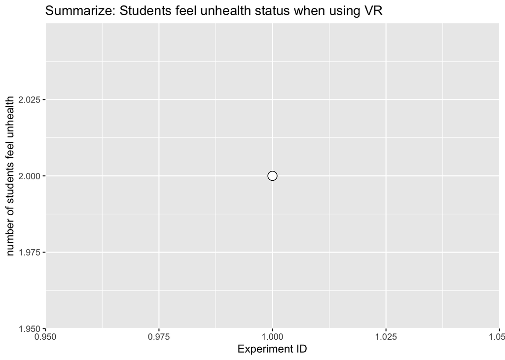

```r
unhealth_data <- vr_data %>%
  group_by(Exp_ID) %>%
  summarize(num_unhealth = sum(`Dizziness` == "yes"|`Headache`== "yes"|`Nausea`== "yes", na.rm = TRUE ))

# draw summarize line plot
ggplot(unhealth_data, aes(x = Exp_ID,
                          y = num_unhealth)) +
  geom_line() +
  geom_point(size = 4, shape = 21, fill = "white") +
  labs(x = "Experiment ID",
       y = "number of students feel unhealth") +
  labs(title = "Summarize: Students feel unhealth status when using VR")
```